# Practice

Sanghoo Yoon

2019년 10월 16일

# 한국복지패널데이터’ 분석

## 한국복지패널데이터

- 한국보건사회연구원 발간
- 가구의 경제활동을 연구해 정책 지원에 반영할 목적
- 2006~2015년까지 전국에서 7000여 가구를 선정해 매년 추적 조사
- 경제활동, 생활실태, 복지욕구 등 수천 개 변수에 대한 정보로 구성
- 현재 2019년 제 14차 한국복지패널조사 진행중

[한국복지패널데이터](https://www.koweps.re.kr:442/main.do)

- 이외에도 [한국고용정보원 고용조사분석정보](https://survey.keis.or.kr/), [한국문화관광연구원 관광지식정보시스템](https://policydb.kcti.re.kr/#/) 등에서 조사한 자료들을 사용자가 쉽게 분석할 수 있도록 공개

## 데이터 분석 준비하기

- 한국보건사회연구원에서 제공하는 데이터는 stata, SPSS, SAS 형태로 제공
- SPSS 파일을 R에서 불러오기 위해선 `foreign` 패키지가 필요합니다.
- `use.value.labels = FALSE`을 사용하여 SPSS에 입력된 코딩 값만 불러오자.
- 위의 옵션을 주지 않으면 라발값에 입력되어 분석에 어려움이 있다.
- 추가로 파일에 한글이 있는 경우 `reencode='utf-8'`를 설정해야한다.
- 한국복지패널자료는 Koweps_etc 에서 다운 받아서 사용하시면 됩니다.
- 용량관계로 github에 올리지 못했습니다.

```r
library(foreign)
library(dplyr)
library(ggplot2)

raw_welfare <- read.spss(file = "F:/work/2018/7. 발표/R_beginner-master/data/survey_data_2015.sav", to.data.frame = T,
                         reencode='utf-8')

raw_welfare <- read.spss(file = "F:/work/2018/7. 발표/R_beginner-master/data/survey_data_2015.sav", to.data.frame = T,
                         use.value.labels = FALSE, reencode='utf-8')

raw_welfare <- read.spss(file = "F:/work/R-work/2019/KERIS/day5/데이터/Koweps_hpc10_2015_beta1.sav",
                         to.data.frame = T, reencode='utf-8')
# 복사본 만들기
welfare <- raw_welfare
```

- 파일을 불러온 다음 꼭 해야할 일은 데이터 검토이다.

```
행과 열의 수는?
```

```r
head(welfare)
tail(welfare)
dim(welfare)
str(welfare)
summary(welfare)
```

- 많은 양의 데이터는 변수가 많고 변수명이 코드로 되어 있어 전체 데이터 구조를 한눈에 파악하는데 어려움이 있다.
- 이 경우 변수명을 쉬운 단어로 바꾼 후 분석에 사용할 변수를 파악해야 한다.
- 설문지를 통해 각 문항이 어떻게 구성되어 있는지 확인해보자.

```
rename함수이 이용하여 변수명을 변경하세요.

sex = h10_g3, # 성별
irth = h10_g4, # 태어난 연도
marriage = h10_g10, # 혼인 상태
religion = h10_g11, # 종교
income = p1002_8aq1, # 월급
code_job = h10_eco9, # 직종 코드
code_region = h10_reg7) # 지역 코드
```

- rename함수로 변경하신 분은 `select`와 `head`를 `%>%`로 연결하여 잘 변경되었는지 확인하세요.

```
##   sex birth marriage religion income code_job code_region
## 1   2  1936        2        2     NA       NA           1
## 2   2  1945        2        2     NA       NA           1
## 3   1  1948        2        2    120      942           1
## 4   1  1942        3        1    200      762           1
## 5   2  1923        2        1     NA       NA           1
## 6   1  1962        1        1     NA      530           1
```

## 데이터 분석 절차

- 1단계 : 변수 검토 및 전처리
- 2단계 : 변수 간 관계 분석

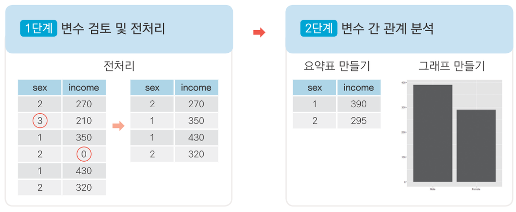

### 성별에 따라 월급이 다를까?

- 관련 변수 : 성별(sex), 수입(income
- 요약표 및 그래프 그리기
1. 변수 검토하기
   - class함수 통해 수치형(numeric)인지 문자형(character)인지 확인하자.
   - table함수를 통해 빈도를 확인해보자.
   - 성별에 1,2외에 다른 데이터가 있으면 데이터를 검토 후 분석해야하기 때문이다.
   - 만약, 이상치가 있으면 ifelse()함수를 이용하여 결측 처리하자.
   - income은 범주형 자료가 아닌 연속형 자료이므로 summary()로 자료를 확인하자.

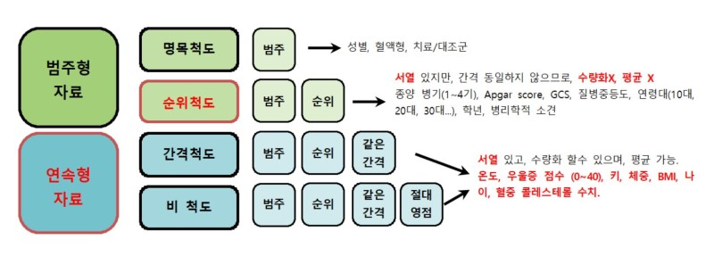

```r
class(welfare$sex)
```

```
## [1] "numeric"
```

```r
class(welfare$income)
```

```
## [1] "numeric"
```

```r
table(welfare$sex)
```

```
##
##    1    2
## 7578 9086
```

```r
summary(welfare$income)
```

```
##    Min. 1st Qu.  Median    Mean 3rd Qu.    Max.    NA's
##     0.0   122.0   192.5   241.6   316.6  2400.0   12030
```

```r
table(is.na(welfare$sex))
```

```
##
## FALSE
## 16664
```

```r
table(is.na(welfare$income))
```

```
##
## FALSE  TRUE
##  4634 12030
```

- 수입의 경우 결측치가 12030으로 수입이 있는 사람에 비해 3배 정도 많음을 알 수 있다.
- 이는 분석 결과에 영향을 미칠 수 있으므로 분석결과 해석에 주의하자.

범주형 자료의 시각화는 barplot(),연속형자료는 boxplot() 또는 hist()가 사용된다.

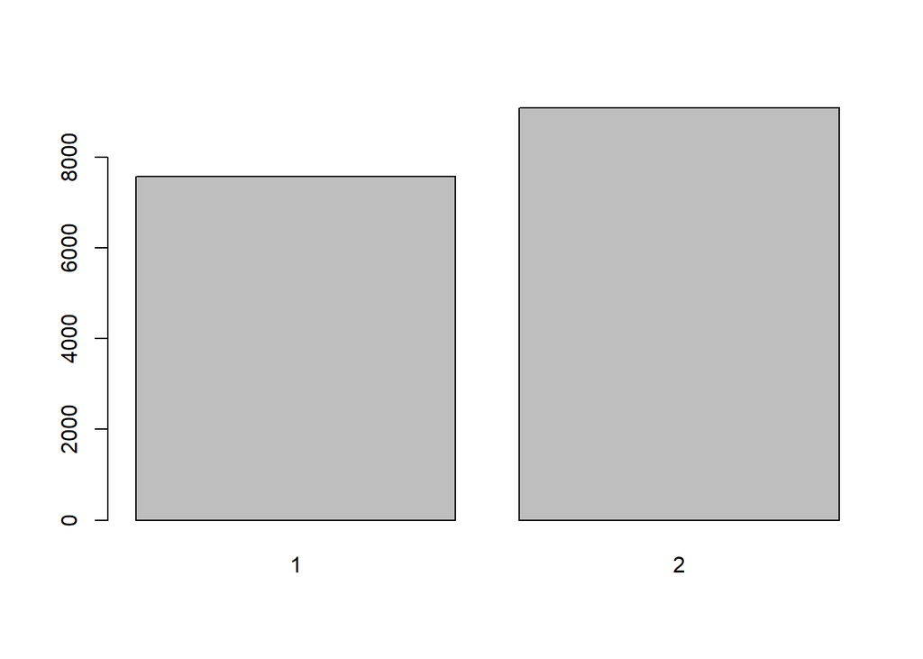

```r
barplot(table(welfare$sex))
```

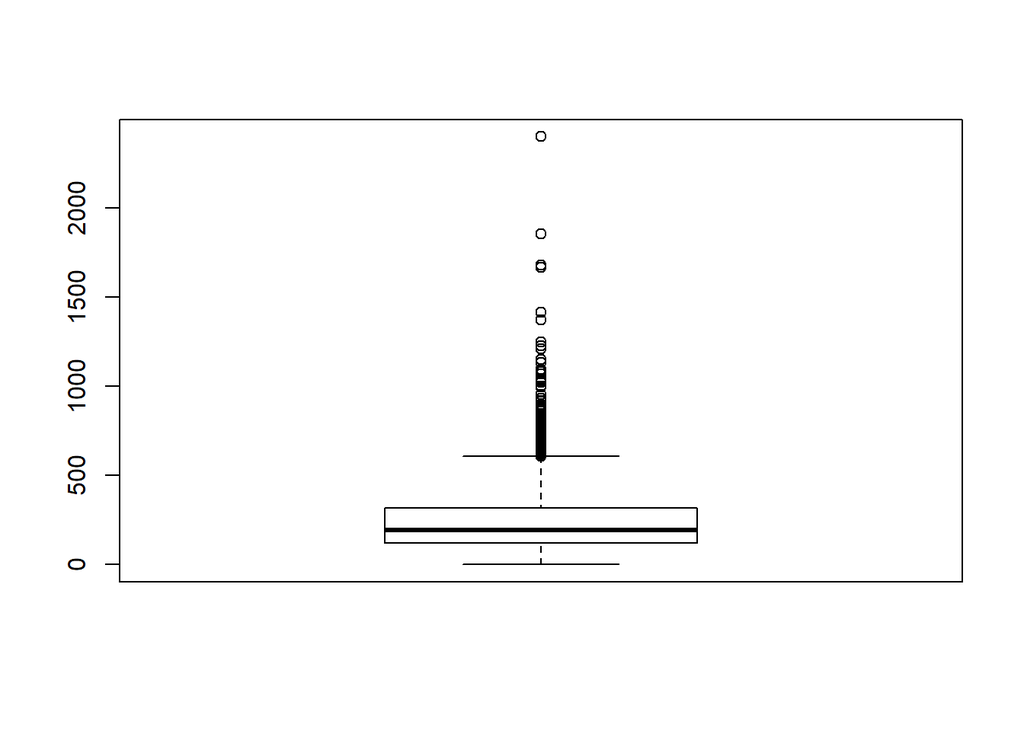

```r
boxplot(welfare$income)
```

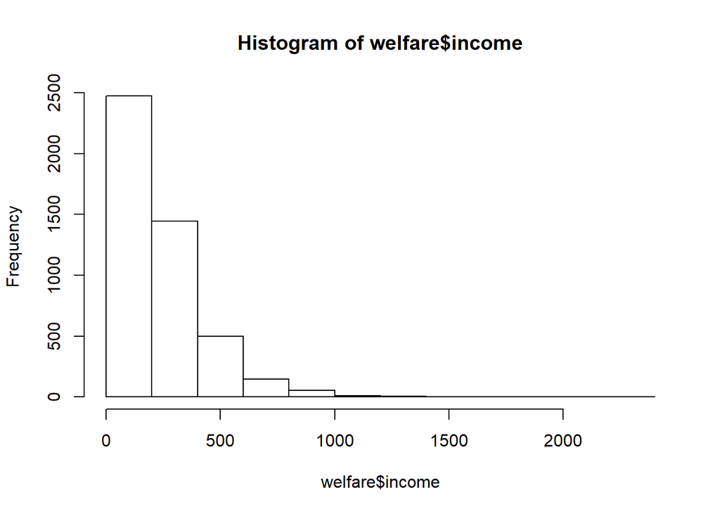

```r
hist(welfare$income)
```

2. 평균표 만들기
- filter로 na를 제거하고 성별(group_by)에 따라 평균 수입을 summarise를 이용해서 만들어 보자.
- 생성된 결과는 gender_income으로 저장하세요.

```
## # A tibble: 2 x 2
##     sex mean_income
##   <dbl>       <dbl>
## 1     1        312.
## 2     2        162.
```

> 추가분석 : 수입(income)이 700이 넘는 사람을 제외한 성별 월급 평균표는?
- barplot을 이용한 시각화

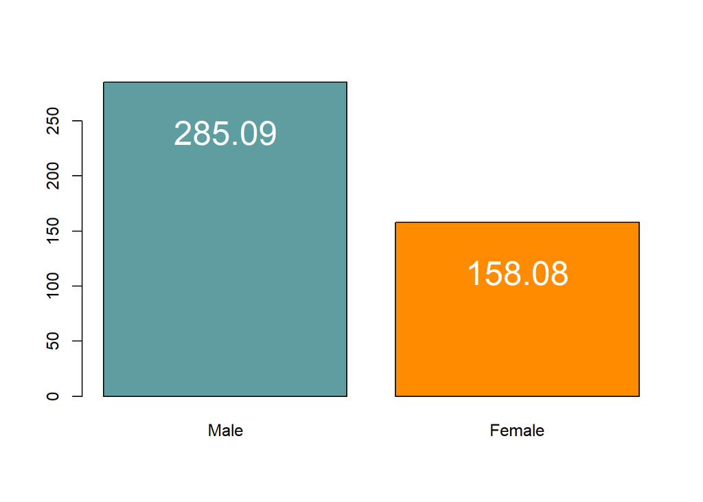

```r
b1<-barplot(gender_income$mean_income, names.arg =c("Male", "Female"), col=c("cadetblue","darkorange"))
text(b1, gender_income$mean_income, labels=round(gender_income$mean_income,2), pos=1, offset = 2, cex=2, col="white")
```

### 나이와 월급의 관계는?

- 관련 변수 : 나이(birth), 수입(income)
- 요약표 및 그래프 그리기
  - 추가변수 생성 : welfare$age=2015-welfare$birth +1
  - hist()함수로 히스토그램 그리기
  - is.na()함수를 이용하여 결측치가 있는지 확인하기

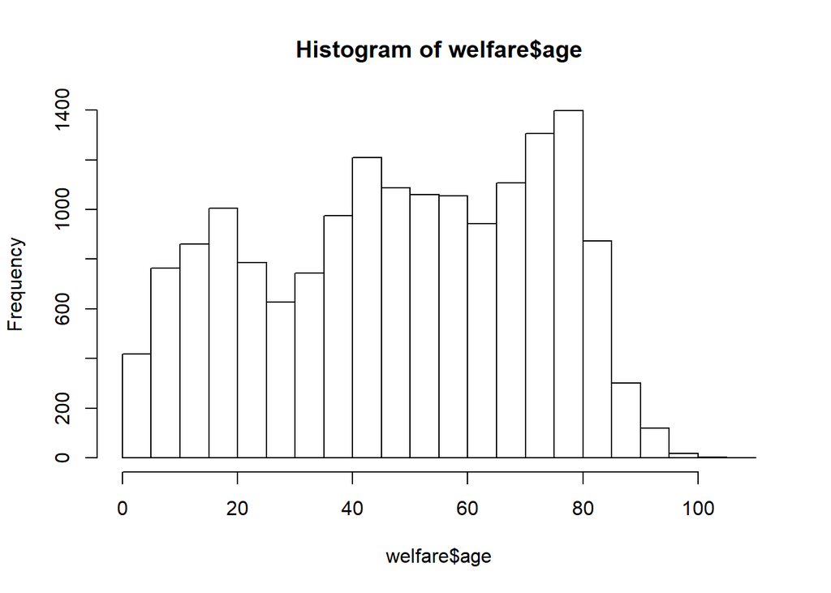

```
##
## FALSE
## 16664
```

- 이제 나이에 따른 월급표를 만들어 보겠습니다.
  - income 중 결측치 제거하기
  - 그룹변수 설정하기 : age
  - 결과를 age_income으로 할당하기

```
## # A tibble: 69 x 2
##      age mean_income
##    <dbl>       <dbl>
##  1    20        121.
##  2    21        106.
##  3    22        130.
##  4    23        142.
##  5    24        134.
##  6    25        145.
##  7    26        158.
##  8    27        188.
##  9    28        205.
## 10    29        189.
## # ... with 59 more rows
```

- barplot함수를 통해 위의 결과를 시각화 하면 아래와 같습니다.
- 또한 arrange와 head를 `%>%`로 연결하면 월급이 많은 연령을 확인할 수 있다.

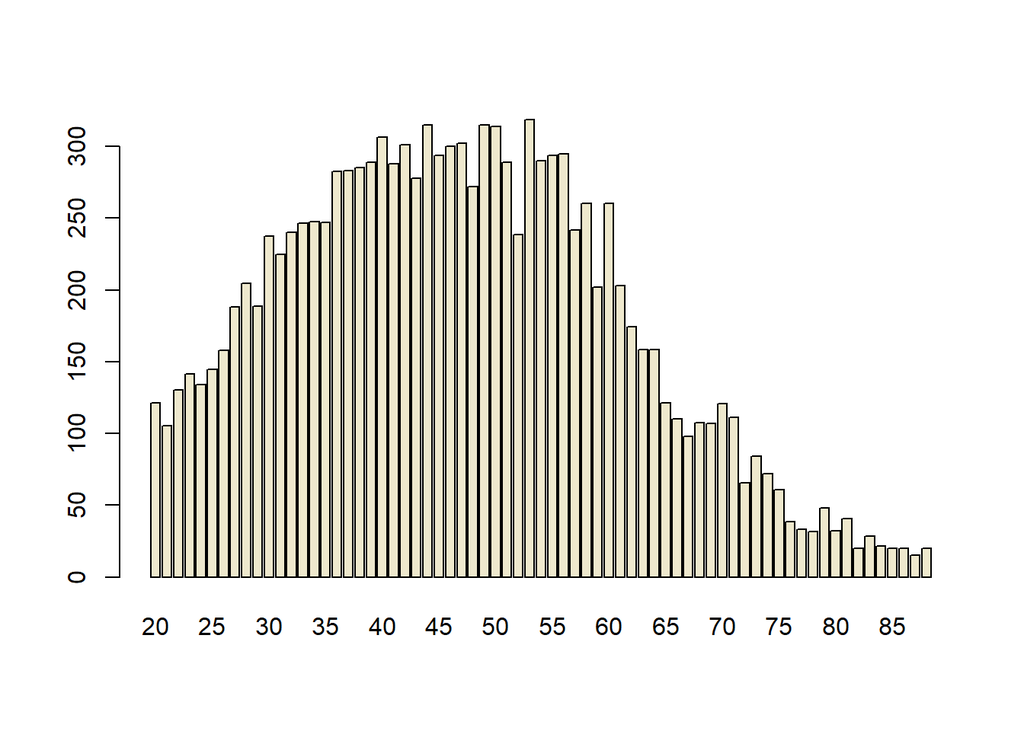

```r
barplot(age_income$mean_income, names.arg=age_income$age, col="cornsilk2")
```

```r
age_income %>% arrange(desc(mean_income)) %>% head
```

```
## # A tibble: 6 x 2
##     age mean_income
##   <dbl>       <dbl>
## 1    53        319.
## 2    49        315.
## 3    44        315.
## 4    50        314.
## 5    40        306.
## 6    47        302.
```

### 연령대와 월급의 관계는?

- 관련변수 : 나이 (age), 수입(income)

> ~29 : Young

> 30~49 : adult

> 50~ : senior
- 위의 기준으로 나이를 연령대로 바꿔 age_group으로 저장해보자.
- `ifelse` 함수를 사용하면 된다.
- 생성된 자료를 table함수로 빈도도 확인해보자.

```
##
##  adult senior  young
##   6049   6281   4334
```

- 이제 연령대별 평균 월급을 계산해보자.

```r
age_group<-welfare %>% filter(!is.na(income)) %>%
         group_by(age_group) %>% summarise(mean_income = mean(income))

age_group
```

```
## # A tibble: 3 x 2
##   age_group mean_income
##   <chr>           <dbl>
## 1 adult            281.
## 2 senior           125.
## 3 young            164.
```

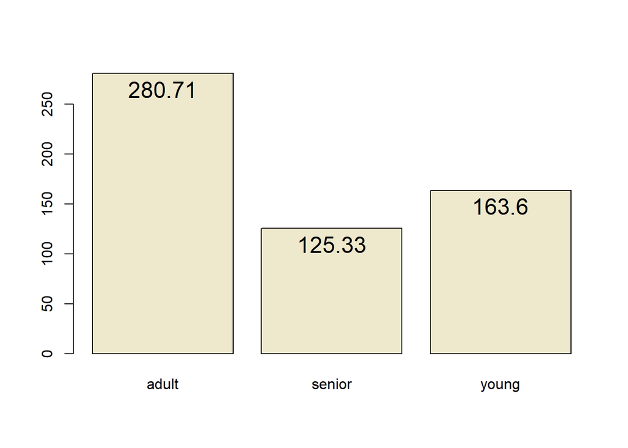

```r
b1<-barplot(age_group$mean_income, names.arg=age_group$age_group, col="cornsilk2")
text(b1, age_group$mean_income, labels=round(age_group$mean_income,2), pos=1, cex=1.5)
```

### 연령대 및 성별 월급 차이를 분석한다면?

```r
sex_income <- welfare %>% filter(!is.na(income)) %>%
        group_by(age_group, sex) %>%
        summarise(mean_income = mean(income))

sex_income
```

```
## # A tibble: 6 x 3
## # Groups:   age_group [3]
##   age_group   sex mean_income
##   <chr>     <dbl>       <dbl>
## 1 adult         1       353.
## 2 adult         2       186.
## 3 senior        1       174.
## 4 senior        2        81.5
## 5 young         1       171.
## 6 young         2       160.
```

### 직업별 월급에는 차이가 있을까?

- 관련변수 : 직업(code_job), 월급(income)
- table()함수를 통해 직업의 빈도를 확인해보자.

```r
table(welfare$code_job)
```

```
##
##  111  120  131  132  133  134  135  139  141  149  151  152  153  159  211
##    2   16   10   11    9    3    7   10   35   20   26   18   15   16    8
##  212  213  221  222  223  224  231  232  233  234  235  236  237  239  241
##    4    3   17   31   12    4   41    5    3    6   48   14    2   29   12
##  242  243  244  245  246  247  248  251  252  253  254  259  261  271  272
##    4   63    4   33   59   77   38   14  111   24   67  109    4   15   11
##  273  274  281  283  284  285  286  289  311  312  313  314  320  330  391
##    4   36   17    8   10   26   16    5  140  260  220   84   75   15    4
##  392  399  411  412  421  422  423  429  431  432  441  442  510  521  522
##   13   87   47   12  124   71    5   14   20   33  154  197  192  353    5
##  530  611  612  613  620  630  710  721  722  730  741  742  743  751  752
##  106 1320   11   40    2   20   29   30   22   16   27    3   34   34    5
##  753  761  762  771  772  773  774  780  791  792  799  811  812  819  821
##   49   69   27   11   61   86    7   17    5   21   45   16    1    6    9
##  822  823  831  832  841  842  843  851  852  853  854  855  861  862  863
##    9   23    5   17   32   10    4   19   13    7   33    9    3   14   17
##  864  871  873  874  875  876  881  882  891  892  899  910  921  922  930
##   31    2  257   34   37    2    2    3    8   19   16  102   31   74  289
##  941  942  951  952  953  991  992  999 1011 1012
##  325   99  125  122   73   45   12  141    2   17
```

- 불러온 자료에는 코드만 있고 직업이 표시되있지 않습니다.
- 직업은 설문지를 살펴보거나 `Koweps_Codebook.xlsx` 파일의 두번째 시트에 있습니다.

```r
library(readxl)
list_job <- read_excel("F:/work/R-work/2019/KERIS/day5/Koweps_Codebook.xlsx", col_names = T, sheet = 2)
head(list_job)
```

```
## # A tibble: 6 x 2
##   code_job job
##      <dbl> <chr>
## 1      111 의회의원 고위공무원 및 공공단체임원
## 2      112 기업고위임원
## 3      120 행정 및 경영지원 관리자
## 4      131 연구 교육 및 법률 관련 관리자
## 5      132 보험 및 금융 관리자
## 6      133 보건 및 사회복지 관련 관리자
```

- 이제 `merge` 함수를 이용해서 직업코드에 직업명을 추가시키겠습니다.

```r
job_income <- welfare %>%
  filter(!is.na(code_job) & !is.na(income)) %>%
  group_by(code_job) %>%
  summarise(mean_income = mean(income)) %>%
  arrange(desc(mean_income))

job_income2 <- merge(job_income, list_job, by="code_job")

head(job_income2)
```

```
##   code_job mean_income                                  job
## 1      111    750.0000  의회의원 고위공무원 및 공공단체임원
## 2      120    563.7633              행정 및 경영지원 관리자
## 3      131    549.9125        연구 교육 및 법률 관련 관리자
## 4      132    726.1800                  보험 및 금융 관리자
## 5      133    375.4460         보건 및 사회복지 관련 관리자
## 6      134    557.4667 문화 예술 디자인 및 영상 관련 관리자
```

이 결과를 barplot으로 그려보면

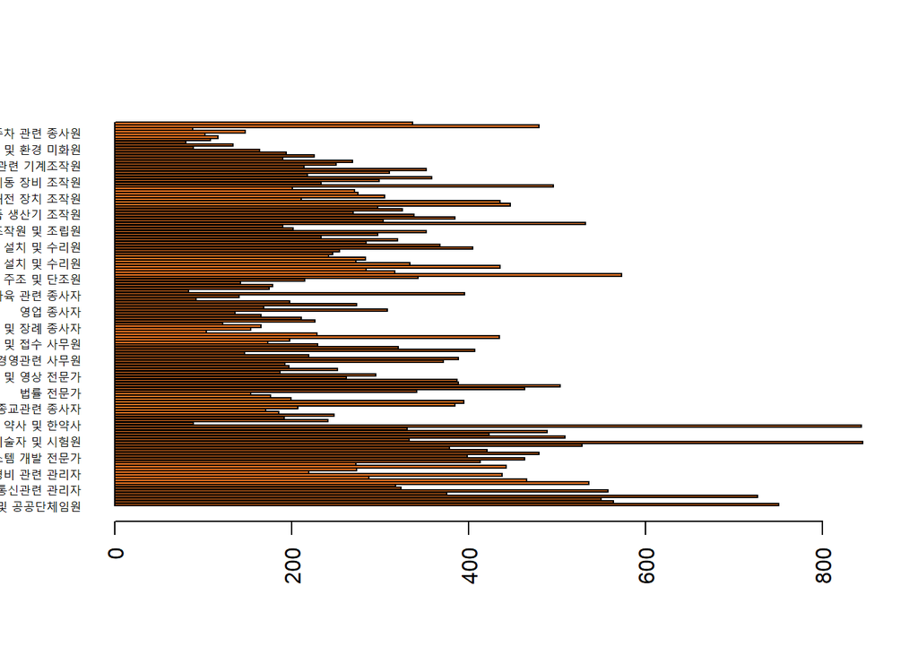

```r
barplot(job_income2$mean_income, names.arg=job_income2$job, horiz= T, col="chocolate2", las=2, cex.names = 0.7)
```

- 평균 월급이 500만원이 넘는 직업은??
- 평균 월급이 낮은 10개의 직업은?

### 종교 유무에 따라 이혼이 영향 받을까?

- 관련변수 : 종교유무(religion), 결혼(marriage)
- welfare$marrige를 빈도분석하면 다음과 같다.

```r
library(knitr)
kable(table(welfare$marriage))
```

| Var1 | Freq |
| --- | --- |
| 0 | 2861 |
| 1 | 8431 |
| 2 | 2117 |
| 3 | 712 |
| 4 | 84 |
| 5 | 2433 |
| 6 | 26 |

- 설문지를 보면 1은 결혼상태이고 3은 이혼이므로 1,3을 제외한 나버지를 NA(결측치) 처리해보자.

```r
welfare$group_marriage <- ifelse(welfare$marriage == 1, "marriage", ifelse(welfare$marriage == 3, "divorce", NA))

table(welfare$group_marriage)
```

```
##
##  divorce marriage
##      712     8431
```

- 이제 생성된 group_marriage를 이용해서 종교 유무에 따른 이혼율을 분석하자.

```r
religion_marriage <- welfare %>%
  filter(!is.na(group_marriage)) %>%
  group_by(religion, group_marriage) %>%
  summarise(n = n()) %>%
  mutate(tot_group = sum(n)) %>%
  mutate(pct = round(n/tot_group*100, 1))

religion_marriage
```

```
## # A tibble: 4 x 5
## # Groups:   religion [2]
##   religion group_marriage     n tot_group   pct
##      <dbl> <chr>          <int>     <int> <dbl>
## 1        1 divorce          328      4541   7.2
## 2        1 marriage        4213      4541  92.8
## 3        2 divorce          384      4602   8.3
## 4        2 marriage        4218      4602  91.7
```

- 참고로 이 자료는 두개의 범주형자료이므로 **교차검증** 을 통해 통계적 가설검정이 이루어진다.

### 노년층이 많은 지역은 어디일까요?

- 관련변수 : 지역(code_region)
- code_region은 숫자가 있어 지역명을 확인하기 어렵다.

```
list_region <- data.frame(code_region = c(1:7),
region = c("서울", "수도권(인천/경기)", "부산/경남/울산", "대구/경북", "대전/충남", "강원/충북", "광주/전남/전북/제주도"))
```

이제 merge를 이용해서 분석을 수행하면 된다.